# Manual T-SHELL for individual chains

The following functions are meant to be used to investigate the pairing of individual chains of interest.

This could be useful for multi-paired chains, abundant chains that have unexpectedly failed to pair, or for chains that expanded between timepoints or are of interest for other experimental reasons.

It could also be useful for exploring possible alterations to the pairing algorithms or for generating figures for sanity checks and to show confident pairing for individual clones.

```
pkgload::load_all("~/git/TIRTLtools")
```

```
ℹ Loading TIRTLtools
```

First, we load already-paired data. If we look at the alpha pseudobulk, we can see here that there are many very abundant clones that were not paired. The most abundant un-paired alpha clone is 15.9% of the repertoire.

```
## Bleakly miH expanded sample -- had issues pairing most abundant clones
data = load_tirtlseq("~/git/Bleakley_miH/data/Bleakley_miH_project", samples = c("Bleakley_miH_4_1_D28_HA1_exp"), verbose = F)
```

```
Loading files from: ~/git/Bleakley_miH/data/Bleakley_miH_project...
Found 30 beta chain pseudo-bulk files.
Found 30 paired chain files.
Loaded 3 files from 1 samples.
0.1 seconds
```

```
data = data %>% identify_paired()
```

```
Annotating data with pairing status by MAD-HYPE and T-SHELL algorithms for sample 1
```

```
un_paired = data$data$Bleakley_miH_4_1_D28_HA1_exp$alpha %>% filter(!is_paired) %>% select(targetSequences, readCount, readFraction, everything())
un_paired
```

| targetSequences | readCount | readFraction | v | j | aaSeqCDR3 | n_wells | readCount_max | readCount_median | sem | max_wells | n_paired_madhype | n_paired_tshell | n_paired | is_paired | is_paired_tshell | is_paired_madhype | paired_status |
| --- | --- | --- | --- | --- | --- | --- | --- | --- | --- | --- | --- | --- | --- | --- | --- | --- | --- |
| TGTGCTGGGCAGAACGGCACTGCCAGTAAACTCACCTTT | 4410227 | 1.586788e-01 | TRAV35 | TRAJ44 | CAGQNGTASKLTF | 192 | 36628 | 22958.5 | 4.600401e-04 | 192 | 0 | 0 | 0 | FALSE | FALSE | FALSE | neither |
| TGTGCAGCCCCCCGCCAAACCTCCTACGACAAGGTGATATTT | 3630673 | 1.306306e-01 | TRAV13-1 | TRAJ50 | CAAPRQTSYDKVIF | 192 | 28142 | 18720.0 | 3.451669e-04 | 192 | 0 | 0 | 0 | FALSE | FALSE | FALSE | neither |
| TGTGCAGCAAATCCCAACCAGTTCTATTTT | 2435105 | 8.761442e-02 | TRAV13-1 | TRAJ49 | CAANPNQFYF | 192 | 19194 | 12699.0 | 2.423772e-04 | 192 | 0 | 0 | 0 | FALSE | FALSE | FALSE | neither |
| TGTGCAGCAATTGGAGGTAACCAGTTCTATTTT | 1110750 | 3.996449e-02 | TRAV13-1 | TRAJ49 | CAAIGGNQFYF | 192 | 9446 | 5792.5 | 1.311614e-04 | 192 | 0 | 0 | 0 | FALSE | FALSE | FALSE | neither |
| TGTGCAGAGAATAACAATGACATGCGCTTT | 781913 | 2.813302e-02 | TRAV5 | TRAJ43 | CAENNNDMRF | 192 | 7061 | 4137.5 | 1.514405e-04 | 192 | 0 | 0 | 0 | FALSE | FALSE | FALSE | neither |
| TGTGCTGTGAGAGCGGGGCCTGGGGCTGGGAGTTACCAACTCACTTTC | 641839 | 2.309319e-02 | TRAV3 | TRAJ28 | CAVRAGPGAGSYQLTF | 192 | 5179 | 3346.5 | 1.601350e-04 | 192 | 0 | 0 | 0 | FALSE | FALSE | FALSE | neither |
| TGTGCTGTGAGAGATCGCCCAGTGCTGGCAACAACCGTAAGCTGATTTGG | 314941 | 1.133149e-02 | TRAV1-2 | TRAJ38 | CAVRDRPV_GNNRKLIW | 192 | 2671 | 1630.5 | 1.009236e-04 | 192 | 0 | 0 | 0 | FALSE | FALSE | FALSE | neither |
| TGTGCTGTGCAAGCCTCCTTAGATGGATAGCAGCTATAAATTGATCTTC | 230868 | 8.306569e-03 | TRAV20 | TRAJ12 | CAVQASLD_DSSYKLIF | 192 | 1826 | 1206.5 | 4.925701e-05 | 192 | 0 | 0 | 0 | FALSE | FALSE | FALSE | neither |
| TGTGCTCCAAAGGCAAACTAATCTTT | 121133 | 4.358333e-03 | TRAV16 | TRAJ37 | CAPK_KLIF | 192 | 1118 | 625.5 | 4.498351e-05 | 192 | 0 | 0 | 0 | FALSE | FALSE | FALSE | neither |
| TGTGCCGTGAAGAAGGATAGCAGCTATAAATTTATCTTC | 84815 | 3.051621e-03 | TRAV12-2 | TRAJ12 | CAVKKDSSYKFIF | 192 | 680 | 439.5 | 2.193955e-05 | 192 | 0 | 0 | 0 | FALSE | FALSE | FALSE | neither |

[output cut: 990 more lines]

## Reading well data and writing to a convenient, fast-loading format

Well-level data comes in the form of a directory of text files (.tsv) with read counts for TCRalpha and TCRbeta chains. Each text file has the chain and the well in the file name. Reading up to 384 text files is slow and can take multiple minutes, even when optimized, so after loading the first time, we write them to a more convenient, fast-loading format.

This format consists of sparse matrices of read counts (wells x clones) for TCRalpha and TCRbeta saved as .rds, an R-specific binary format. The matrices are “dgCMatrix”, a column-based format that allows for extremely fast extraction of any column (read counts for one clone across all wells).

This only needs to be run once.

```
# Note: "Bleakley_miH_4_1_D28_HA1_exp" is MVP175, UD-21, A1 to H24
dir_in1 = "/Volumes/thomagrp/home/common/TIRTL/tirtlSeq_data/MVP175_Bleakley_miH/clones_MVP175_Bleakley_miH/TCR_clones_UD21/"
dir_out1 = "/Volumes/thomagrp/home/common/nclark52/temp/MVP175_Bleakley_miH/Bleakley_miH_4_1_D28_HA1_exp/"
prefix1 = "Bleakley_miH_4_1_D28_HA1_exp"
wells1 = get_well_subset(row_range = 1:8, col_range = 1:24)

### run once
# write_well_data_to_binary(
#   folder_in = dir_in1, folder_out = dir_out1, prefix = prefix1, wells = wells1,
#   in_file_type = ".tsv", out_file_type = ".rds",
#   well_pos = 3, to_sparse_matrix = TRUE
#   )
```

Next, we load the well-level data and run `plot_tshell()` for the most abundant un-paired clone:

```
well_data = load_well_counts_binary(dir_out1, prefix1, lazy = FALSE)
nuc_seq = un_paired$targetSequences[1] ## most abundant un-paired clone (15% of repertoire)
res = plot_tshell(well_data, nuc_seq, chain="alpha", interactive = F,
                  plot_log_scale = F, n_plot = 9, loss_frac_cutoff = 0.5)
res$plots
```

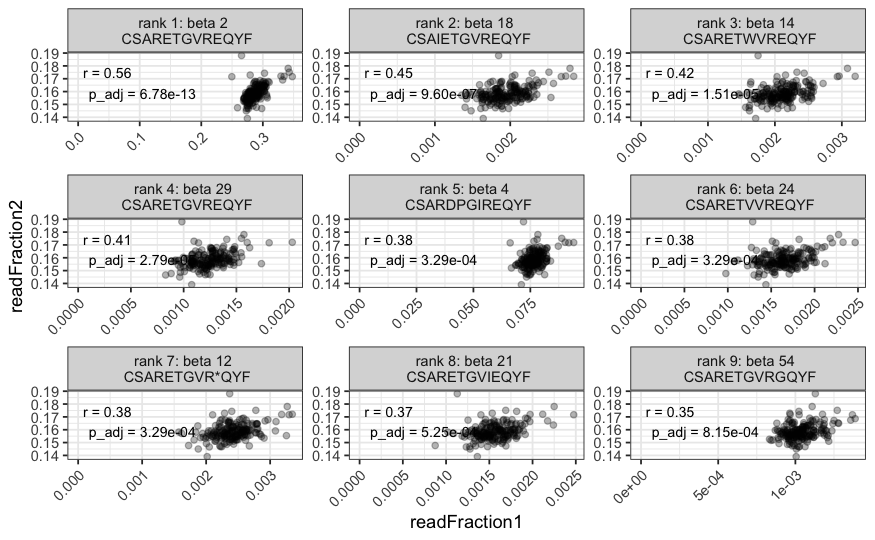

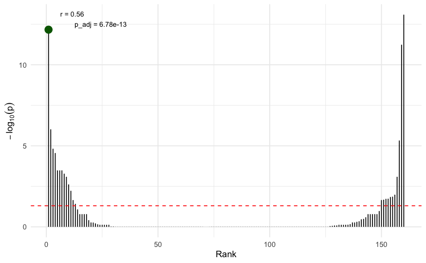

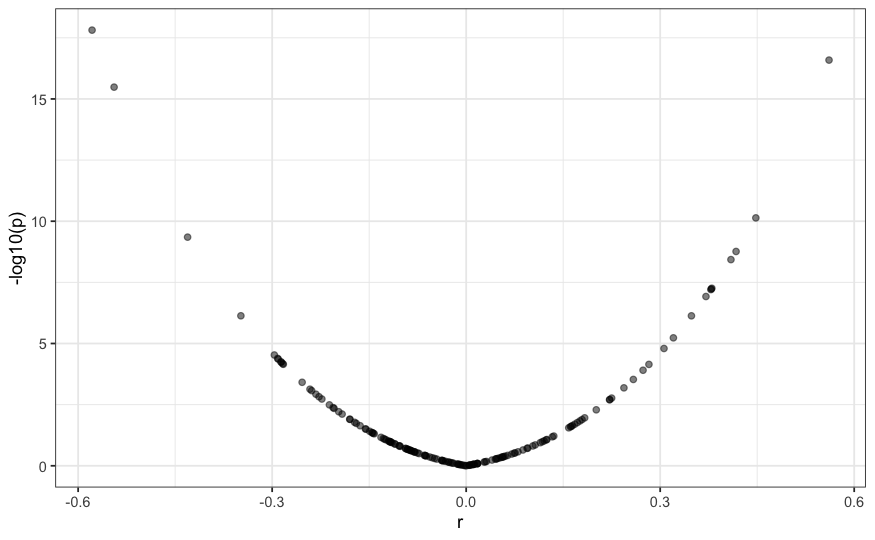

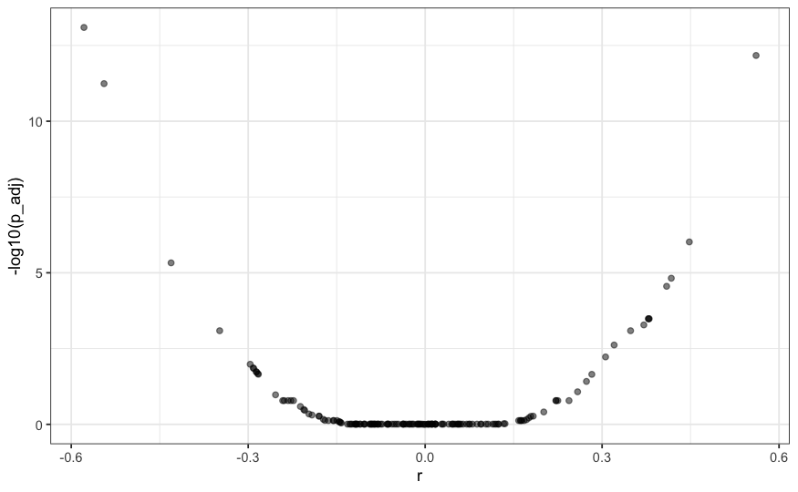

```
res$data$df_top_n
```

| chain | row_id | aaSeqCDR3 | r | t | p | p_adj | wa | wb | wij | n | targetSequences | v | j | r_log_log | p_log_log | readCount_alpha | readCount_beta | readFraction_alpha | readFraction_beta | wi | wj | p_adj_old | loss_a_frac | loss_b_frac | loss_frac_sum | rank | chain_name | fisher_pval |
| --- | --- | --- | --- | --- | --- | --- | --- | --- | --- | --- | --- | --- | --- | --- | --- | --- | --- | --- | --- | --- | --- | --- | --- | --- | --- | --- | --- | --- |
| beta | 2 | CSARETGVREQYF | 0.5610616 | 9.342768 | 2.578877e-17 | 6.781157e-13 | 192 | 192 | 192 | 192 | TGCAGTGCTAGAGAAACAGGGGTTAGAGAGCAGTACTTC | TRBV20-1*00 | TRBJ2-7*00 | 0.5565182 | 5.241574e-17 | 4410227 | 10482467 | 0.1586788 | 0.286267206 | 0 | 0 | 7.841957e-02 | 0 | 0 | 0 | 1 | rank 1: beta 2 \n CSARETGVREQYF | 1 |
| beta | 18 | CSAIETGVREQYF | 0.4479110 | 6.905467 | 7.303834e-11 | 9.602716e-07 | 192 | 192 | 192 | 192 | TGCAGTGCTATAGAAACAGGGGTTAGAGAGCAGTACTTC | TRBV20-1*00 | TRBJ2-7*00 | 0.4315672 | 4.113361e-10 | 4410227 | 71481 | 0.1586788 | 0.001952085 | 0 | 0 | 2.220980e+05 | 0 | 0 | 0 | 2 | rank 2: beta 18 \n CSAIETGVREQYF | 1 |
| beta | 14 | CSARETWVREQYF | 0.4173204 | 6.329910 | 1.724555e-09 | 1.511573e-05 | 192 | 192 | 192 | 192 | TGCAGTGCTAGAGAAACATGGGTTAGAGAGCAGTACTTC | TRBV20-1*00 | TRBJ2-7*00 | 0.4029424 | 6.856365e-09 | 4410227 | 77511 | 0.1586788 | 0.002116759 | 0 | 0 | 5.244099e+06 | 0 | 0 | 0 | 3 | rank 3: beta 14 \n CSARETWVREQYF | 1 |
| beta | 29 | CSARETGVREQYF | 0.4094174 | 6.185615 | 3.712461e-09 | 2.789119e-05 | 192 | 192 | 192 | 192 | TGCAGTGCTAGAGAAACAGGTGTTAGAGAGCAGTACTTC | TRBV20-1*00 | TRBJ2-7*00 | 0.4037659 | 6.346355e-09 | 4410227 | 45673 | 0.1586788 | 0.001247291 | 0 | 0 | 1.128901e+07 | 0 | 0 | 0 | 4 | rank 4: beta 29 \n CSARETGVREQYF | 1 |
| beta | 4 | CSARDPGIREQYF | 0.3798585 | 5.660254 | 5.505053e-08 | 3.285084e-04 | 192 | 192 | 192 | 192 | TGCAGTGCTAGAGATCCCGGGATAAGGGAGCAGTACTTC | TRBV20-1*00 | TRBJ2-7*00 | 0.3739191 | 9.171945e-08 | 4410227 | 2799762 | 0.1586788 | 0.076459105 | 0 | 0 | 1.673999e+08 | 0 | 0 | 0 | 5 | rank 5: beta 4 \n CSARDPGIREQYF | 1 |
| beta | 24 | CSARETVVREQYF | 0.3790525 | 5.646227 | 5.903444e-08 | 3.285084e-04 | 192 | 192 | 192 | 192 | TGCAGTGCTAGAGAAACAGTGGTTAGAGAGCAGTACTTC | TRBV20-1*00 | TRBJ2-7*00 | 0.3582149 | 3.370248e-07 | 4410227 | 60562 | 0.1586788 | 0.001653896 | 0 | 0 | 1.795144e+08 | 0 | 0 | 0 | 6 | rank 6: beta 24 \n CSARETVVREQYF | 1 |
| beta | 12 | CSARETGVR*QYF | 0.3783992 | 5.634867 | 6.246595e-08 | 3.285084e-04 | 192 | 192 | 192 | 192 | TGCAGTGCTAGAGAAACAGGGGTTAGATAGCAGTACTTC | TRBV20-1*00 | TRBJ2-7*00 | 0.3699393 | 1.283975e-07 | 4410227 | 88668 | 0.1586788 | 0.002421447 | 0 | 0 | 1.899491e+08 | 0 | 0 | 0 | 7 | rank 7: beta 12 \n CSARETGVR*QYF | 1 |
| beta | 21 | CSARETGVIEQYF | 0.3707652 | 5.502852 | 1.197843e-07 | 5.249548e-04 | 192 | 192 | 192 | 192 | TGCAGTGCTAGAGAAACAGGGGTTATAGAGCAGTACTTC | TRBV20-1*00 | TRBJ2-7*00 | 0.3521365 | 5.475598e-07 | 4410227 | 57490 | 0.1586788 | 0.001570003 | 0 | 0 | 3.642452e+08 | 0 | 0 | 0 | 8 | rank 8: beta 21 \n CSARETGVIEQYF | 1 |
| beta | 54 | CSARETGVRGQYF | 0.3483130 | 5.121906 | 7.392171e-07 | 8.150293e-04 | 192 | 192 | 192 | 192 | TGCAGTGCTAGAGAAACAGGGGTTAGAGGGCAGTACTTC | TRBV20-1*00 | TRBJ2-7*00 | 0.3393677 | 1.469139e-06 | 4410227 | 38051 | 0.1586788 | 0.001039140 | 0 | 0 | 2.247842e+09 | 0 | 0 | 0 | 9 | rank 9: beta 54 \n CSARETGVRGQYF | 1 |